IMDB Movie Clustering and Genre  
Classification  
Thinkful Data Science  
Marshall Mamiya Unsupervised Learning Capstone

# Dataset Information

[Dataset](https://www.kaggle.com/PromptCloudHQ/imdb-data) contains 1,000 IMDB top movies between 2006-2016. Features include: Rank, Title, Genre, Description, Director, Actors, Year, Runtime, Rating, Votes, Revenue, and Metascore.

```python
df.head()
```

|  | Rank | Title | Genre | Description | Director | Actors | Year | Runtime (Minutes) | Rating | Votes | Revenue (Millions) | Metascore |
| --- | --- | --- | --- | --- | --- | --- | --- | --- | --- | --- | --- | --- |
| 0 | 1 | Guardians of the Galaxy | Action,Adventure,Sci-Fi | A group of intergalactic criminals are forced ... | James Gunn | Chris Pratt, Vin Diesel, Bradley Cooper, Zoe S... | 2014 | 121 | 8.1 | 757074 | 333.13 | 76.0 |
| 1 | 2 | Prometheus | Adventure,Mystery,Sci-Fi | Following clues to the origin of mankind, a te... | Ridley Scott | Noomi Rapace, Logan Marshall-Green, Michael Fa... | 2012 | 124 | 7.0 | 485820 | 126.46 | 65.0 |
| 2 | 3 | Split | Horror,Thriller | Three girls are kidnapped by a man with a diag... | M. Night Shyamalan | James McAvoy, Anya Taylor-Joy, Haley Lu Richar... | 2016 | 117 | 7.3 | 157606 | 138.12 | 62.0 |
| 3 | 4 | Sing | Animation,Comedy,Family | In a city of humanoid animals, a hustling thea... | Christophe Lourdelet | Matthew McConaughey,Reese Witherspoon, Seth Ma... | 2016 | 108 | 7.2 | 60545 | 270.32 | 59.0 |
| 4 | 5 | Suicide Squad | Action,Adventure,Fantasy | A secret government agency recruits some of th... | David Ayer | Will Smith, Jared Leto, Margot Robbie, Viola D... | 2016 | 123 | 6.2 | 393727 | 325.02 | 40.0 |

# Data Cleaning

## Null Values

```python
df.isnull().sum()/df.isnull().count()*100
```

```
Rank                   0.0
Title                  0.0
Genre                  0.0
Description            0.0
Director               0.0
Actors                 0.0
Year                   0.0
Runtime (Minutes)      0.0
Rating                 0.0
Votes                  0.0
Revenue (Millions)    12.8
Metascore              6.4
dtype: float64
```

```python
#mean imputation for each respective null feature

df['Revenue (Millions)'].fillna(df['Revenue (Millions)'].mean(), inplace=True)
df['Metascore'].fillna(df['Metascore'].mean(), inplace=True)
```

## Outliers

- Revenue and votes columns have outliers
- Large difference between their respective 75th percentile and max value

```python
df.describe()
```

|  | Rank | Year | Runtime (Minutes) | Rating | Votes | Revenue (Millions) | Metascore |
| --- | --- | --- | --- | --- | --- | --- | --- |
| count | 1000.000000 | 1000.000000 | 1000.000000 | 1000.000000 | 1.000000e+03 | 1000.000000 | 1000.000000 |
| mean | 500.500000 | 2012.783000 | 113.172000 | 6.723200 | 1.698083e+05 | 82.956376 | 58.985043 |
| std | 288.819436 | 3.205962 | 18.810908 | 0.945429 | 1.887626e+05 | 96.412043 | 16.634858 |
| min | 1.000000 | 2006.000000 | 66.000000 | 1.900000 | 6.100000e+01 | 0.000000 | 11.000000 |
| 25% | 250.750000 | 2010.000000 | 100.000000 | 6.200000 | 3.630900e+04 | 17.442500 | 47.750000 |
| 50% | 500.500000 | 2014.000000 | 111.000000 | 6.800000 | 1.107990e+05 | 60.375000 | 58.985043 |
| 75% | 750.250000 | 2016.000000 | 123.000000 | 7.400000 | 2.399098e+05 | 99.177500 | 71.000000 |
| max | 1000.000000 | 2016.000000 | 191.000000 | 9.000000 | 1.791916e+06 | 936.630000 | 100.000000 |

```python
outlier_cols = ['Revenue (Millions)', 'Votes']
for col in outlier_cols:
    q25, q75 = np.percentile(df[col], [25,75])
    iqr = q75 - q25
    min_val = q25 - iqr
    max_val = q75 + iqr


    min_outliers, max_outliers = len(np.where(df[col] < min_val)[0]), len(np.where(df[col] > max_val)[0])
    min_pct, max_pct = min_outliers/len(df), max_outliers/len(df)
    df['winsorized_'+col] = winsorize(df[col], (min_pct, max_pct))
    max_val = df[col].max()
    max_cap_val = df['winsorized_'+col].max()

    print()
    print(col)
    print()
    print('Min Outliers: ', min_outliers)
    print('Max Outliers: ', max_outliers)
    print('Max Original: ', max_val)
    print('Max Capped: ', max_cap_val)
```

```
Revenue (Millions)

Min Outliers:  0
Max Outliers:  113
Max Original:  936.63
Max Capped:  180.19

Votes

Min Outliers:  0
Max Outliers:  84
Max Original:  1791916
Max Capped:  442082
```

# Data Exploration

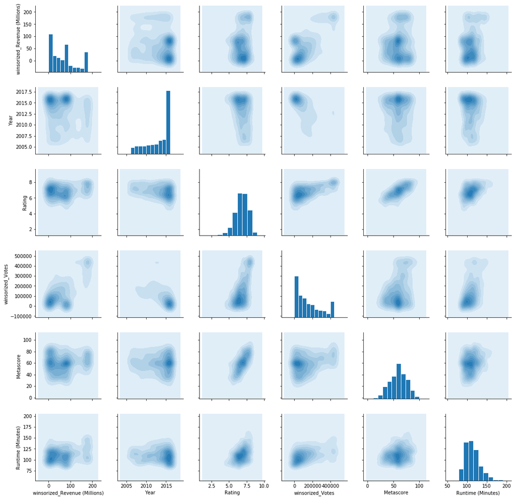

```python
plot_features = ['winsorized_Revenue (Millions)', 'Year', 'Rating', 'winsorized_Votes', 'Metascore', 'Runtime (Minutes)']

g = plt.figure(figsize=(.25,.25))
g = sns.PairGrid(df[plot_features])
g = g.map_lower(sns.kdeplot, shade=True)
g = g.map_upper(sns.kdeplot, shade=True)
g = g.map_diag(plt.hist, edgecolor="w")


plt.show()
```

```python
df['Genre'].value_counts()
```

```
Action,Adventure,Sci-Fi       50
Drama                         48
Comedy,Drama,Romance          35
Comedy                        32
Drama,Romance                 31
Animation,Adventure,Comedy    27
Action,Adventure,Fantasy      27
Comedy,Drama                  27
Comedy,Romance                26
Crime,Drama,Thriller          24
Crime,Drama,Mystery           23
Action,Adventure,Drama        18
Action,Crime,Drama            17
Horror,Thriller               16
Drama,Thriller                15
Action,Adventure,Comedy       14
Biography,Drama,History       14
Adventure,Family,Fantasy      14
Biography,Drama               14
Action,Comedy,Crime           12
Action,Crime,Thriller         12
Horror                        11
Action,Adventure,Thriller     11
Crime,Drama                   10
Action,Thriller                9
Biography,Crime,Drama          9
Thriller                       9
Animation,Action,Adventure     9
Horror,Mystery,Thriller        9
Action,Biography,Drama         8
Adventure,Comedy,Drama         8
Biography,Drama,Sport          8
Drama,Mystery,Thriller         8
Mystery,Thriller               7
Action,Drama,Thriller          7
Comedy,Crime,Drama             7
Biography,Comedy,Drama         7
Action,Sci-Fi,Thriller         7
Drama,Mystery,Sci-Fi           6
Adventure,Drama,Fantasy        6
```

[output cut: 97 more lines]

```
Drama,Musical,Romance          1
Biography,History,Thriller     1
Drama,Romance,War              1
Drama,Fantasy,Musical          1
Action,Horror,Mystery          1
Drama,Horror,Musical           1
Fantasy,Mystery,Thriller       1
Action,Comedy,Mystery          1
Comedy,Romance,Sport           1
Action,Drama,War               1
Crime,Drama,Music              1
Adventure,Biography            1
Adventure,Drama,Western        1
Adventure,Comedy,Fantasy       1
Name: Genre, Length: 207, dtype: int64
```

# Feature Engineering

## Word Embedding

Convert movie descriptions into word embeddings:

- Lowercase
- Split at spaces
- Remove punctuations and stops words
- Filter out words that have a total count of less than five within the entire dataset description word count
- Transform into word vectors (vector length = 100)
- Final vector is the average of all word vectors for each respective movie

```python
df['word_list'] = df['Description'].apply(lambda x: x.translate(str.maketrans('', '', string.punctuation)).strip().lower().split())

stop_words = list(stopwords.words())

def remove_stopwords(word_list):
    filtered_word_list = [word for word in word_list if word not in stop_words]
    return filtered_word_list

df['clean_word_list'] = df['word_list'].apply(remove_stopwords)

word_embeddings = Word2Vec(df['clean_word_list'].tolist(), min_count=5)
```

```python
word_embeddings.wv.similar_by_word('fight')
```

```
[('one', 0.7942277789115906),
 ('life', 0.7892246246337891),
 ('find', 0.776583194732666),
 ('woman', 0.770760715007782),
 ('new', 0.7695791721343994),
 ('mysterious', 0.7672905921936035),
 ('together', 0.7639696598052979),
 ('turns', 0.7634577751159668),
 ('becomes', 0.76008540391922),
 ('agent', 0.7599658966064453)]
```

```python
def vector_funct(word_list):
    filter_word_list = [word for word in word_list if word in word_embeddings]
    if len(filter_word_list) != 0:
        return sum([word_embeddings.wv[word] for word in filter_word_list ]) / len(filter_word_list)
    else:
        return np.zeros(100)


df['vector'] = df['clean_word_list'].apply(vector_funct)
```

## Target Variable: Key Genre

```python
def get_key_genre(genre_list):
    genre_list = genre_list.split(',')
    key_genre_list = [genre for genre in genre_list if genre in key_genre]
    if len(key_genre_list) == 1:
        return key_genre_list[0]

    elif len(key_genre_list) > 1:
        return 'multiple'

    else:
        return 'NA'


df['Genre'].value_counts()
key_genre = ['Action', 'Drama', 'Comedy']

df['key_genre'] = df['Genre'].apply(get_key_genre)
df['key_genre'].value_counts()
```

```
Drama       342
multiple    215
Action      187
Comedy      135
NA          121
Name: key_genre, dtype: int64
```

- Action movies have higher revenue and votes
- Drama movies have higher ratings and metascore
- Majority of movies come out around 2014-2016

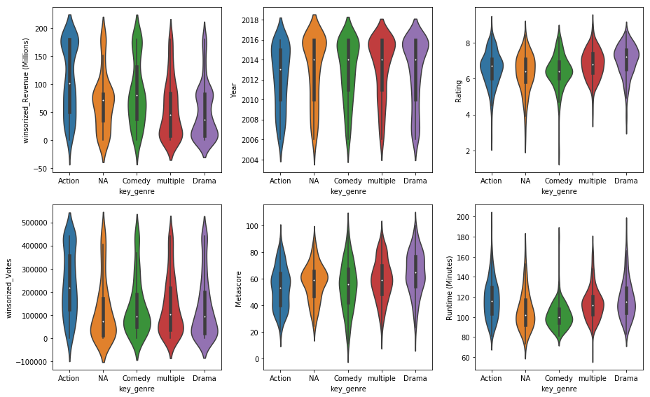

```python
plt.figure(figsize=(13,8))
for i,col in enumerate(plot_features):
    plt.subplot(2,3,i+1)
    sns.violinplot(x='key_genre', y=plot_features[i], data=df)

plt.tight_layout()
plt.show()
```

## One-Hot Encoded Words

```python
#get all clean words from description column
all_words = [word for word_list in df['clean_word_list'] for word in word_list]

#get frequency of words
all_words_dict = dict(Counter(all_words))

genre_list = list(df['key_genre'].unique())

top_genre_word_dict = {}
genre_word_dict = {}
dummy_words = []

for genre in genre_list:

    #get all words within genre
    genre_words = [word for word_list in df['clean_word_list'][df['key_genre'] == genre] for word in word_list]
    genre_word_dict[genre] = dict(Counter(genre_words))

    #get top 5 most frequent words within respective genre
    top_genre_words = dict(Counter(genre_words).most_common()[:20])

    #add top words to genre_word_dict
    top_genre_word_dict[genre] = top_genre_words


    x_genre = genre
    #get list of other genre for ratios
    other_genres = [genre for genre in genre_list if genre != x_genre]
    for word in top_genre_word_dict[x_genre].keys():
        for genre in other_genres:
            try:
                other_genre_freq = genre_word_dict[genre][word]
            except KeyError:
                other_genre_freq = 0

            x_genre_freq = top_genre_word_dict[x_genre][word]

            ratio = other_genre_freq / x_genre_freq
            if ratio < .9:
                dummy_words.append(word)

dummy_words = list(np.unique(dummy_words))
```

```python
dummy_cols = []

for word in dummy_words:
    df['DV_'+word] = 0
    dummy_cols.append('DV_'+word)
for i,word_list in enumerate(df['clean_word_list']):
    for word in dummy_words:
        if word in word_list:
            df.at[i, 'DV_'+word] = 1
        else:
            df.at[i, 'DV_'+word] = 0
```

```python
# Description Length Feature

df['description_len'] = df['word_list'].apply(lambda x: len(x))
```

# Clustering

Separate supervised data from unsupervised data

Supervised Data:

```
- Explanatory include continous variables, dummy variables and word embeddings
- Movies with multiple key genres are filtered out
    - Models will have a hard time distinguishing between two movies such as a action and drama movie vs. action movie
    - A movie with multiple key genre will have a large similarity with a movie that has a single related key genre
```

Unsupervised data:

```
- Explanatory include continous variables, dummy variables and word embeddings
- Includes movies that fall under multiple key genres since clustering based on genres isn't explicit in unsupervised models and more data the better
```

```python
standard_s = StandardScaler()

continous_features = ['winsorized_Revenue (Millions)', 'winsorized_Votes', 'Rating', 'Metascore', 'Runtime (Minutes)']

cluster_vectors = np.vstack((df['vector']))
cluster_feature_df = df[dummy_cols + continous_features]
cluster_data = np.hstack((cluster_vectors, cluster_feature_df))

cluster_normalize_data = standard_s.fit_transform(cluster_data)

classification_df = df[df['key_genre']!= 'multiple'].copy()
classification_feature_df = classification_df[dummy_cols + continous_features]
classification_vectors = np.vstack((classification_df['vector']))
classification_data = np.hstack((classification_vectors, classification_feature_df))

classification_normalize_data = standard_s.fit_transform(classification_data)
```

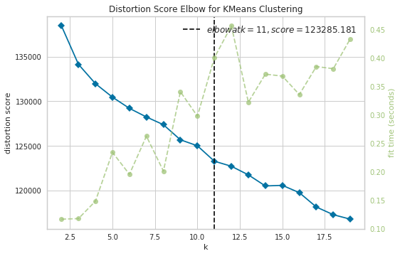

```python
km = KMeans()
ke = KElbowVisualizer(km, k=(2,20))
ke.fit(cluster_normalize_data)
ke.show()
```

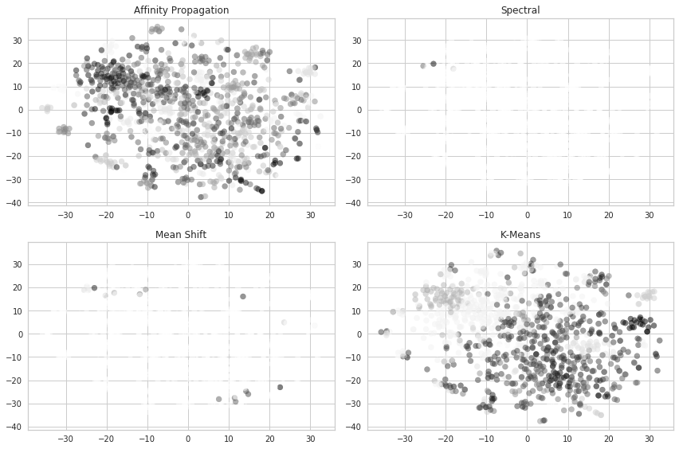

```python
plot_tsne_clusters(ap_pred, sc_pred, ms_pred, km_pred, tsne_results)
```

```python
pd.crosstab(km_pred, df['key_genre'], margins=True)
```

| key_genre row_0 | Action | Comedy | Drama | NA | multiple | All |
| --- | --- | --- | --- | --- | --- | --- |
| 0 | 4 | 6 | 3 | 0 | 8 | 21 |
| 1 | 61 | 39 | 110 | 35 | 64 | 309 |
| 2 | 16 | 3 | 23 | 5 | 14 | 61 |
| 3 | 0 | 8 | 5 | 1 | 11 | 25 |
| 4 | 16 | 6 | 24 | 6 | 14 | 66 |
| 5 | 7 | 9 | 12 | 1 | 3 | 32 |
| 6 | 9 | 3 | 10 | 1 | 9 | 32 |
| 7 | 9 | 19 | 37 | 12 | 16 | 93 |
| 8 | 44 | 37 | 83 | 46 | 57 | 267 |
| 9 | 8 | 3 | 34 | 11 | 16 | 72 |
| 10 | 13 | 2 | 1 | 3 | 3 | 22 |
| All | 187 | 135 | 342 | 121 | 215 | 1000 |

- Cluster assignments somewhat represent the key genre feature
- K-Means clusterd the best
- Bigger clusters have more variance in regards to key genres
- Clustering with only continous and one-hot encoded words created distinct clusters but no useful information
- Clustering with only word vectors creatd one big blob

## Investigate Clusters

```python
#gets cluster count, top 3 genres and top 5 words within each cluster

def cluster_info(cluster_col, df):
    for cluster in list(df[cluster_col].value_counts().keys()):
            cluster_df = df[df[cluster_col] == cluster]
            cluster_words = [word for word_list in cluster_df['clean_word_list'] for word in word_list]
            genre_list = [genre for genre_list in cluster_df['Genre'].value_counts().keys().tolist() for genre in genre_list.split(',')]
            top_genres = Counter(genre_list).most_common()[:3]

            print()
            print('Cluster', cluster)
            print('Cluster Count: ', len(cluster_df))
            print('Top 3 Genres: \n', top_genres)
            print()
            print('Top 5 most frequent words: \n', Counter(cluster_words).most_common()[:5])
```

## K-Means Clusters

- Majority of clusters share similar averages for continous features
- Significant difference between cluster's average for one-hot ecncoded words

```python
df.groupby('km_clusters').mean()
```

| km_clusters | Rank | Year | Runtime (Minutes) | Rating | Votes | Revenue (Millions) | Metascore | winsorized_Revenue (Millions) | winsorized_Votes | DV_agent | DV_american | DV_back | DV_best | DV_boy | DV_city | DV_discover | DV_discovers | DV_earth | DV_evil | DV_family | DV_fight | DV_find | DV_finds | DV_forced | DV_forces | DV_former | DV_friend | DV_friends | DV_girl | … |
| --- | --- | --- | --- | --- | --- | --- | --- | --- | --- | --- | --- | --- | --- | --- | --- | --- | --- | --- | --- | --- | --- | --- | --- | --- | --- | --- | --- | --- | --- | --- |
| 0 | 424.333333 | 2012.666667 | 109.142857 | 6.795238 | 236103.523810 | 141.779524 | 63.952381 | 98.824286 | 184975.761905 | 0.000000 | 0.000000 | 0.095238 | 0.095238 | 0.047619 | 1.000000 | 0.000000 | 0.000000 | 0.000000 | 0.047619 | 0.000000 | 0.000000 | 0.142857 | 0.000000 | 0.095238 | 0.047619 | 0.000000 | 0.047619 | 0.047619 | 0.142857 | … |
| 1 | 488.152104 | 2012.624595 | 116.016181 | 6.807443 | 186051.265372 | 83.310925 | 59.044339 | 71.854874 | 169317.695793 | 0.032362 | 0.042071 | 0.029126 | 0.006472 | 0.016181 | 0.009709 | 0.006472 | 0.016181 | 0.009709 | 0.016181 | 0.032362 | 0.042071 | 0.012945 | 0.022654 | 0.009709 | 0.032362 | 0.035599 | 0.000000 | 0.048544 | 0.032362 | … |
| 2 | 421.098361 | 2013.065574 | 122.081967 | 6.883607 | 228368.786885 | 117.448228 | 58.523609 | 84.989867 | 201706.459016 | 0.032787 | 0.000000 | 0.016393 | 0.000000 | 0.032787 | 0.000000 | 0.016393 | 0.049180 | 0.000000 | 0.016393 | 0.016393 | 0.000000 | 0.000000 | 0.032787 | 0.032787 | 0.049180 | 0.032787 | 0.049180 | 0.032787 | 0.016393 | … |
| 3 | 533.560000 | 2011.960000 | 108.120000 | 6.752000 | 183487.880000 | 77.898365 | 60.478205 | 72.627965 | 165979.120000 | 0.000000 | 0.000000 | 0.040000 | 0.040000 | 0.000000 | 0.000000 | 0.040000 | 0.000000 | 0.000000 | 0.000000 | 0.000000 | 0.040000 | 0.000000 | 0.080000 | 0.120000 | 0.000000 | 0.080000 | 0.080000 | 0.120000 | 0.080000 | … |
| 4 | 487.712121 | 2012.060606 | 117.469697 | 7.040909 | 237101.075758 | 96.551144 | 62.544321 | 78.435538 | 196798.924242 | 0.000000 | 0.015152 | 0.000000 | 0.000000 | 0.000000 | 0.000000 | 0.000000 | 0.015152 | 0.015152 | 0.015152 | 0.000000 | 0.000000 | 0.000000 | 0.000000 | 0.030303 | 0.000000 | 0.015152 | 0.000000 | 0.015152 | 0.000000 | … |
| 5 | 468.812500 | 2012.656250 | 110.625000 | 6.425000 | 159106.875000 | 78.544149 | 53.217815 | 70.530086 | 152976.406250 | 0.000000 | 0.000000 | 0.031250 | 0.031250 | 0.062500 | 0.000000 | 0.031250 | 0.031250 | 0.000000 | 0.000000 | 0.093750 | 0.000000 | 1.000000 | 0.031250 | 0.000000 | 0.031250 | 0.000000 | 0.031250 | 0.093750 | 0.000000 | … |
| 6 | 526.468750 | 2012.312500 | 119.218750 | 6.884375 | 223065.906250 | 75.683922 | 58.093283 | 62.475485 | 173297.750000 | 0.187500 | 0.000000 | 0.031250 | 0.062500 | 0.000000 | 0.031250 | 0.000000 | 0.031250 | 0.125000 | 0.000000 | 0.000000 | 0.187500 | 0.093750 | 0.093750 | 0.000000 | 0.062500 | 0.000000 | 0.031250 | 0.000000 | 0.000000 | … |
| 7 | 541.989247 | 2013.096774 | 112.172043 | 6.751613 | 125909.064516 | 69.212035 | 60.977369 | 63.484293 | 122839.290323 | 0.010753 | 0.032258 | 0.064516 | 0.053763 | 0.043011 | 0.000000 | 0.064516 | 0.032258 | 0.032258 | 0.021505 | 0.193548 | 0.000000 | 0.075269 | 0.172043 | 0.043011 | 0.000000 | 0.010753 | 0.021505 | 0.150538 | 0.107527 | … |
| 8 | 521.677903 | 2013.089888 | 109.093633 | 6.526592 | 124499.857678 | 70.351217 | 57.403486 | 62.260056 | 121568.119850 | 0.029963 | 0.033708 | 0.037453 | 0.044944 | 0.026217 | 0.000000 | 0.056180 | 0.022472 | 0.018727 | 0.026217 | 0.093633 | 0.018727 | 0.000000 | 0.059925 | 0.029963 | 0.014981 | 0.037453 | 0.041199 | 0.037453 | 0.048689 | … |
| 9 | 543.444444 | 2013.000000 | 107.402778 | 6.658333 | 120375.569444 | 56.166278 | 60.179932 | 53.791972 | 114559.888889 | 0.041667 | 0.013889 | 0.041667 | 0.000000 | 0.083333 | 0.000000 | 0.055556 | 0.027778 | 0.000000 | 0.000000 | 0.041667 | 0.000000 | 0.041667 | 0.041667 | 0.013889 | 0.055556 | 0.013889 | 0.069444 | 0.013889 | 0.013889 | … |
| 10 | 402.954545 | 2012.545455 | 112.727273 | 6.718182 | 333922.772727 | 206.908597 | 58.862956 | 119.687688 | 269891.090909 | 0.045455 | 0.000000 | 0.045455 | 0.000000 | 0.000000 | 0.000000 | 0.000000 | 0.000000 | 0.090909 | 0.136364 | 0.000000 | 0.090909 | 0.045455 | 0.045455 | 0.045455 | 0.000000 | 0.045455 | 0.045455 | 0.090909 | 0.045455 | … |

```python
cluster_info('km_clusters', df)
```

```
Cluster 1
Cluster Count:  309
Top 3 Genres:
 [('Drama', 59), ('Action', 42), ('Adventure', 31)]

Top 5 most frequent words:
 [('two', 24), ('story', 18), ('friends', 15), ('woman', 15), ('american', 14)]

Cluster 8
Cluster Count:  267
Top 3 Genres:
 [('Drama', 43), ('Action', 32), ('Comedy', 29)]

Top 5 most frequent words:
 [('new', 38), ('life', 35), ('must', 25), ('family', 25), ('one', 22)]

Cluster 7
Cluster Count:  93
Top 3 Genres:
 [('Drama', 25), ('Comedy', 16), ('Thriller', 14)]

Top 5 most frequent words:
 [('life', 43), ('new', 27), ('two', 24), ('family', 19), ('young', 18)]

Cluster 9
Cluster Count:  72
Top 3 Genres:
 [('Drama', 32), ('Action', 16), ('Thriller', 13)]

Top 5 most frequent words:
 [('young', 70), ('woman', 24), ('home', 10), ('years', 9), ('mysterious', 8)]

Cluster 4
Cluster Count:  66
Top 3 Genres:
 [('Drama', 23), ('Action', 16), ('Adventure', 11)]

Top 5 most frequent words:
 [('irish', 5), ('everything', 3), ('may', 3), ('police', 3), ('heist', 3)]

```

[output cut: 32 more lines]

```
Cluster 10
Cluster Count:  22
Top 3 Genres:
 [('Action', 11), ('Adventure', 9), ('Comedy', 5)]

Top 5 most frequent words:
 [('stop', 22), ('must', 5), ('group', 4), ('together', 4), ('heroes', 4)]

Cluster 0
Cluster Count:  21
Top 3 Genres:
 [('Comedy', 11), ('Action', 8), ('Drama', 8)]

Top 5 most frequent words:
 [('city', 22), ('new', 11), ('york', 10), ('young', 4), ('save', 3)]
```

- Cluster 10 seems to be a group of high revenue action movies
- Top words reflect the definition of action movies

```python
df[df['km_clusters']==10]
```

|  | Rank | Title | Genre | Description | Director | Actors | Year | Runtime (Minutes) | Rating | Votes | Revenue (Millions) | Metascore | winsorized_Revenue (Millions) | winsorized_Votes | word_list | clean_word_list | vector | key_genre | DV_agent | DV_american | DV_back | DV_best | DV_boy | DV_city | DV_discover | DV_discovers | DV_earth | DV_evil | DV_family | … |
| --- | --- | --- | --- | --- | --- | --- | --- | --- | --- | --- | --- | --- | --- | --- | --- | --- | --- | --- | --- | --- | --- | --- | --- | --- | --- | --- | --- | --- | --- | --- |
| 0 | 1 | Guardians of the Galaxy | Action,Adventure,Sci-Fi | A group of intergalactic criminals are forced ... | James Gunn | Chris Pratt, Vin Diesel, Bradley Cooper, Zoe S... | 2014 | 121 | 8.1 | 757074 | 333.130000 | 76.000000 | 180.190000 | 442082 | [a, group, of, intergalactic, criminals, are, ... | [group, intergalactic, criminals, forced, work... | [0.0008302467, -0.0036675397, 0.0040834295, -0... | Action | 0 | 0 | 0 | 0 | 0 | 0 | 0 | 0 | 0 | 0 | 0 | … |
| 50 | 51 | Star Wars: Episode VII - The Force Awakens | Action,Adventure,Fantasy | Three decades after the defeat of the Galactic... | J.J. Abrams | Daisy Ridley, John Boyega, Oscar Isaac, Domhna... | 2015 | 136 | 8.1 | 661608 | 936.630000 | 81.000000 | 180.190000 | 442082 | [three, decades, after, the, defeat, of, the, ... | [three, decades, defeat, galactic, empire, new... | [-0.0022921073, -0.0020458165, 0.002416239, 0.... | Action | 0 | 0 | 0 | 0 | 0 | 0 | 0 | 0 | 0 | 0 | 0 | … |
| 76 | 77 | The Avengers | Action,Sci-Fi | Earth's mightiest heroes must come together an... | Joss Whedon | Robert Downey Jr., Chris Evans, Scarlett Johan... | 2012 | 143 | 8.1 | 1045588 | 623.280000 | 69.000000 | 180.190000 | 442082 | [earths, mightiest, heroes, must, come, togeth... | [earths, mightiest, heroes, must, together, le... | [-0.00054045685, -0.0035844152, 0.0024190932, ... | Action | 0 | 0 | 0 | 0 | 0 | 0 | 0 | 0 | 0 | 0 | 0 | … |
| 79 | 80 | Ghostbusters | Action,Comedy,Fantasy | Following a ghost invasion of Manhattan, paran... | Paul Feig | Melissa McCarthy, Kristen Wiig, Kate McKinnon,... | 2016 | 116 | 5.3 | 147717 | 128.340000 | 60.000000 | 128.340000 | 147717 | [following, a, ghost, invasion, of, manhattan,... | [following, ghost, invasion, manhattan, parano... | [-0.0021609224, -0.002853781, 0.0016947456, 0.... | multiple | 0 | 0 | 0 | 0 | 0 | 0 | 0 | 0 | 0 | 0 | 0 | … |
| 91 | 92 | Warcraft | Action,Adventure,Fantasy | As an Orc horde invades the planet Azeroth usi... | Duncan Jones | Travis Fimmel, Paula Patton, Ben Foster, Domin... | 2016 | 123 | 7.0 | 187547 | 47.170000 | 32.000000 | 47.170000 | 187547 | [as, an, orc, horde, invades, the, planet, aze... | [orc, horde, invades, planet, azeroth, using, ... | [-0.0019053228, -0.0032955655, 0.0039509493, 0... | Action | 0 | 0 | 0 | 0 | 0 | 0 | 0 | 0 | 0 | 1 | 0 | … |
| 94 | 95 | Avengers: Age of Ultron | Action,Adventure,Sci-Fi | When Tony Stark and Bruce Banner try to jump-s... | Joss Whedon | Robert Downey Jr., Chris Evans, Mark Ruffalo, ... | 2015 | 141 | 7.4 | 516895 | 458.990000 | 66.000000 | 180.190000 | 442082 | [when, tony, stark, and, bruce, banner, try, t... | [tony, stark, bruce, banner, try, jumpstart, d... | [-0.0010940477, -0.0017656278, 0.0025899229, 0... | Action | 0 | 0 | 0 | 0 | 0 | 0 | 0 | 0 | 0 | 0 | 0 | … |
| 133 | 134 | Whiplash | Drama,Music | A promising young drummer enrolls at a cut-thr... | Damien Chazelle | Miles Teller, J.K. Simmons, Melissa Benoist, P... | 2014 | 107 | 8.5 | 477276 | 13.090000 | 88.000000 | 13.090000 | 442082 | [a, promising, young, drummer, enrolls, at, a,... | [promising, young, drummer, enrolls, cutthroat... | [-0.0028494606, -0.0037862537, 0.0027448414, 0... | Drama | 0 | 0 | 0 | 0 | 0 | 0 | 0 | 0 | 0 | 0 | 0 | … |
| 150 | 151 | The BFG | Adventure,Family,Fantasy | An orphan little girl befriends a benevolent g... | Steven Spielberg | Mark Rylance, Ruby Barnhill, Penelope Wilton,J... | 2016 | 117 | 6.4 | 50853 | 55.470000 | 66.000000 | 55.470000 | 50853 | [an, orphan, little, girl, befriends, a, benev... | [orphan, little, girl, befriends, benevolent, ... | [-0.002131435, -0.0017224941, 0.0025307604, 0.... | NA | 0 | 0 | 0 | 0 | 0 | 0 | 0 | 0 | 0 | 0 | 0 | … |
| 205 | 206 | X: First Class | Action,Adventure,Sci-Fi | In 1962, the United States government enlists ... | Matthew Vaughn | James McAvoy, Michael Fassbender, Jennifer Law... | 2011 | 132 | 7.8 | 550011 | 146.410000 | 65.000000 | 146.410000 | 442082 | [in, 1962, the, united, states, government, en... | [1962, united, states, government, enlists, he... | [-0.0017687373, -0.00380461, 0.0024443087, 0.0... | Action | 0 | 0 | 0 | 0 | 0 | 0 | 0 | 0 | 0 | 0 | 0 | … |
| 269 | 270 | Satanic | Horror | Four friends on their way to Coachella stop of... | Jeffrey G. Hunt | Sarah Hyland, Steven Krueger, Justin Chon, Cla... | 2016 | 85 | 3.7 | 2384 | 82.956376 | 58.985043 | 82.956376 | 2384 | [four, friends, on, their, way, to, coachella,... | [four, friends, way, coachella, stop, angeles,... | [-0.0002978084, -0.0017400143, 0.0020407452, 0... | NA | 0 | 0 | 0 | 0 | 0 | 0 | 0 | 0 | 0 | 0 | 0 | … |
| 323 | 324 | In Time | Action,Sci-Fi,Thriller | In a future where people stop aging at 25, but... | Andrew Niccol | Justin Timberlake, Amanda Seyfried, Cillian Mu... | 2011 | 109 | 6.7 | 319025 | 37.550000 | 53.000000 | 37.550000 | 319025 | [in, a, future, where, people, stop, aging, at... | [future, people, stop, aging, 25, engineered, ... | [-0.0006328549, -0.0028139881, 0.0022885834, 0... | Action | 0 | 0 | 0 | 0 | 0 | 0 | 0 | 0 | 0 | 0 | 0 | … |
| 384 | 385 | The Lego Movie | Animation,Action,Adventure | An ordinary Lego construction worker, thought ... | Phil Lord | Chris Pratt, Will Ferrell, Elizabeth Banks, Wi... | 2014 | 100 | 7.8 | 266508 | 257.760000 | 83.000000 | 180.190000 | 266508 | [an, ordinary, lego, construction, worker, tho... | [ordinary, lego, construction, worker, thought... | [-0.00019943301, -0.0019967882, 0.0031473723, ... | Action | 0 | 0 | 0 | 0 | 0 | 0 | 0 | 0 | 0 | 1 | 0 | … |
| 432 | 433 | World War Z | Action,Adventure,Horror | Former United Nations employee Gerry Lane trav... | Marc Forster | Brad Pitt, Mireille Enos, Daniella Kertesz, Ja... | 2013 | 116 | 7.0 | 494819 | 202.350000 | 63.000000 | 180.190000 | 442082 | [former, united, nations, employee, gerry, lan... | [former, united, nations, employee, gerry, lan... | [-0.0018506926, -0.002254228, 0.0025716287, 0.... | Action | 0 | 0 | 0 | 0 | 0 | 0 | 0 | 0 | 0 | 0 | 0 | … |
| 496 | 497 | Men in Black 3 | Action,Adventure,Comedy | Agent J travels in time to M.I.B.'s early days... | Barry Sonnenfeld | Will Smith, Tommy Lee Jones, Josh Brolin,Jemai... | 2012 | 106 | 6.8 | 278379 | 179.020000 | 58.000000 | 179.020000 | 278379 | [agent, j, travels, in, time, to, mibs, early,... | [agent, travels, time, mibs, early, days, 1969... | [-0.0013723839, -0.0046905493, 0.0038811578, 0... | multiple | 1 | 0 | 0 | 0 | 0 | 0 | 0 | 0 | 0 | 0 | 0 | … |
| 575 | 576 | Clash of the Titans | Action,Adventure,Fantasy | Perseus demigod, son of Zeus, battles the mini... | Louis Leterrier | Sam Worthington, Liam Neeson, Ralph Fiennes,Ja... | 2010 | 106 | 5.8 | 238206 | 163.190000 | 39.000000 | 163.190000 | 238206 | [perseus, demigod, son, of, zeus, battles, the... | [perseus, demigod, zeus, battles, minions, und... | [-0.00041450787, -0.007108722, 0.0027057473, 0... | Action | 0 | 0 | 0 | 0 | 0 | 0 | 0 | 0 | 1 | 0 | 0 | … |
| 581 | 582 | The Last Airbender | Action,Adventure,Family | Follows the adventures of Aang, a young succes... | M. Night Shyamalan | Noah Ringer, Nicola Peltz, Jackson Rathbone,De... | 2010 | 103 | 4.2 | 125129 | 82.956376 | 20.000000 | 82.956376 | 125129 | [follows, the, adventures, of, aang, a, young,... | [follows, adventures, aang, young, successor, ... | [-0.0013051945, -0.003109759, 0.0030181834, 0.... | Action | 0 | 0 | 0 | 0 | 0 | 0 | 0 | 0 | 1 | 0 | 0 | … |
| 749 | 750 | Percy Jackson: Sea of Monsters | Adventure,Family,Fantasy | In order to restore their dying safe haven, th... | Thor Freudenthal | Logan Lerman, Alexandra Daddario, Brandon T. J... | 2013 | 106 | 5.9 | 91684 | 68.560000 | 39.000000 | 68.560000 | 91684 | [in, order, to, restore, their, dying, safe, h... | [order, restore, dying, safe, poseidon, friend... | [-0.0016895521, -0.0018659739, 0.004037054, 0.... | NA | 0 | 0 | 0 | 0 | 0 | 0 | 0 | 0 | 0 | 1 | 0 | … |
| 770 | 771 | Quantum of Solace | Action,Adventure,Thriller | James Bond descends into mystery as he tries t... | Marc Forster | Daniel Craig, Olga Kurylenko, Mathieu Amalric,... | 2008 | 106 | 6.6 | 347798 | 168.370000 | 58.000000 | 168.370000 | 347798 | [james, bond, descends, into, mystery, as, he,... | [james, bond, descends, mystery, tries, stop, ... | [-0.0021025953, -0.0019509154, 0.0015586718, 0... | Action | 0 | 0 | 0 | 0 | 0 | 0 | 0 | 0 | 0 | 0 | 0 | … |
| 797 | 798 | Despicable Me 2 | Animation,Adventure,Comedy | When Gru, the world's most super-bad turned su... | Pierre Coffin | Steve Carell, Kristen Wiig, Benjamin Bratt, Mi... | 2013 | 98 | 7.4 | 304837 | 368.050000 | 62.000000 | 180.190000 | 304837 | [when, gru, the, worlds, most, superbad, turne... | [gru, worlds, superbad, turned, superdad, recr... | [-0.0014057561, -0.0028830732, 0.0033689546, 0... | Comedy | 0 | 0 | 1 | 0 | 0 | 0 | 0 | 0 | 0 | 0 | 0 | … |
| 806 | 807 | Prince of Persia: The Sands of Time | Action,Adventure,Fantasy | A young fugitive prince and princess must stop... | Mike Newell | Jake Gyllenhaal, Gemma Arterton, Ben Kingsley,... | 2010 | 116 | 6.6 | 233148 | 90.760000 | 50.000000 | 90.760000 | 233148 | [a, young, fugitive, prince, and, princess, mu... | [young, fugitive, prince, princess, must, stop... | [-0.0015236344, -0.0022985542, 0.004089474, 0.... | Action | 0 | 0 | 0 | 0 | 0 | 0 | 0 | 0 | 0 | 0 | 0 | … |
| 888 | 889 | Piranha 3D | Comedy,Horror,Thriller | After a sudden underwater tremor sets free sco... | Alexandre Aja | Elisabeth Shue, Jerry O'Connell, Richard Dreyf... | 2010 | 88 | 5.5 | 75262 | 25.000000 | 53.000000 | 25.000000 | 75262 | [after, a, sudden, underwater, tremor, sets, f... | [sudden, underwater, tremor, sets, free, score... | [-0.001609547, -0.0042507607, 0.0027763846, 0.... | Comedy | 0 | 0 | 0 | 0 | 0 | 0 | 0 | 0 | 0 | 0 | 0 | … |
| 895 | 896 | Planet Terror | Action,Comedy,Horror | After an experimental bio-weapon is released, ... | Robert Rodriguez | Rose McGowan, Freddy Rodríguez, Josh Brolin,Ma... | 2007 | 105 | 7.1 | 174553 | 82.956376 | 55.000000 | 82.956376 | 174553 | [after, an, experimental, bioweapon, is, relea... | [experimental, bioweapon, released, turning, t... | [-0.0011850838, -0.0012772181, 0.003164594, 0.... | multiple | 0 | 0 | 0 | 0 | 0 | 0 | 0 | 0 | 0 | 0 | 0 | … |